# DEG-tables_merge_filter

Veronica Radice

13/04/2021

# Aim: cross-species DEG comparison

## Comparison of potential shared response

### Import libraries

```r
library(tidyverse)
```

### Set working directory

```r
setwd("~/Documents/Rprojects/postdoc\ Rprojects/ODU_postdoc_Rprojects/Paper_Ojo_gene-expression/Porites_astreoides/orthofinder/")
```

#### import Past seq2iso table

Carly Kenkel’s P. astreoides transcriptome reference

```r
past_seq2iso <- read.table("~/Documents/Postdoc/ODU_postdoc/projects/Ojo_gene-expression/database/pastreoides_2014/pastreoides_may2014/past_seq2iso_suffixed.tab", header = FALSE, sep = "\t", stringsAsFactors=T)

past_seq2iso <- past_seq2iso %>%
  dplyr::rename(isotig = V1,
         gene = V2)

head(past_seq2iso)
```

```
##             isotig               gene
## 1 isotig00001_Past isogroup00001_Past
## 2 isotig00002_Past isogroup00001_Past
## 3 isotig00003_Past isogroup00001_Past
## 4 isotig00004_Past isogroup00001_Past
## 5 isotig00005_Past isogroup00001_Past
## 6 isotig00006_Past isogroup00001_Past
```

#### import Ppor seq2iso

Same as Past table, but with _Ppor suffix

```r
ppor_seq2iso <- read.table("~/Documents/Postdoc/ODU_postdoc/projects/Ojo_gene-expression/database/pastreoides_2014/pastreoides_may2014/past_seq2iso_suffixed_Ppor.tab", header = FALSE, sep = "\t", stringsAsFactors=T)

ppor_seq2iso <- ppor_seq2iso %>%
  dplyr::rename(isotig_Ppor = V1,
         gene_Ppor = V2)

head(ppor_seq2iso)
```

```
##        isotig_Ppor          gene_Ppor
## 1 isotig00001_Ppor isogroup00001_Ppor
## 2 isotig00002_Ppor isogroup00001_Ppor
## 3 isotig00003_Ppor isogroup00001_Ppor
## 4 isotig00004_Ppor isogroup00001_Ppor
## 5 isotig00005_Ppor isogroup00001_Ppor
## 6 isotig00006_Ppor isogroup00001_Ppor
```

Same transcriptome reference, just used different suffixes for mapping of the different species

```r
seq2iso <- cbind(past_seq2iso, ppor_seq2iso)
head(seq2iso)
```

```
##             isotig               gene      isotig_Ppor          gene_Ppor
## 1 isotig00001_Past isogroup00001_Past isotig00001_Ppor isogroup00001_Ppor
## 2 isotig00002_Past isogroup00001_Past isotig00002_Ppor isogroup00001_Ppor
## 3 isotig00003_Past isogroup00001_Past isotig00003_Ppor isogroup00001_Ppor
## 4 isotig00004_Past isogroup00001_Past isotig00004_Ppor isogroup00001_Ppor
## 5 isotig00005_Past isogroup00001_Past isotig00005_Ppor isogroup00001_Ppor
## 6 isotig00006_Past isogroup00001_Past isotig00006_Ppor isogroup00001_Ppor
```

# 1. Merge DESeq2 output with OrthoFinder output

Use Sid.v.Past_longestContig orthologue output.

## Import OrthoFinder orthogroups with species orthologues

Output file from OrthoFinder2: N0.tsv is a tab separated text file. Each row contains the genes belonging to a single orthogroup. The genes from each orthogroup are organized into columns, one per species. Additional columns give the HOG (Hierarchical Orthogroup) ID and the node in the gene tree from which the HOG was determined (note, this can be above the root of the clade containing the genes). This file effectively replaces the orthogroups in Orthogroups/Orthogroups.tsv from Markov clustering using MCL.

*Hierarchical orthogroup splitting:* When analysing the gene trees, a nested hierarchical group (any HOG other than N0, the HOG at the level of the last common ancestor of all species) may sometimes have lost its genes from the earliest diverging species and then duplicated before the first extant genes. The two first diverging clades will then be paralogous even though the evidence suggests they belong to the same HOG. For most analyses it is often better to split these clades into separate groups.

```r
orthogroups <- read.table("~/Documents/Rprojects/postdoc\ Rprojects/ODU_postdoc_Rprojects/Paper_Ojo_gene-expression/Porites_astreoides/orthofinder/Sid.v.Past_longestContig/Phylogenetic_Hierarchical_Orthogroups/N0.tsv", header = TRUE, sep = "\t", stringsAsFactors=F) #row.names = 1

orthogroups <- orthogroups %>%
  dplyr::rename(orthogroup = HOG,
         gene_Sid = X19222_Sid_GoodCoral_500lnThresh_Final,
         isotig = X29422_past_LongestContig_suffixed)

dim(orthogroups)
```

```
## [1] 4435    5
```

```r
head(orthogroups)
```

```
##      orthogroup        OG Gene.Tree.Parent.Clade
## 1 N0.HOG0000000 OG0000000                     n1
## 2 N0.HOG0000001 OG0000000                     n3
## 3 N0.HOG0000002 OG0000000                     n8
## 4 N0.HOG0000003 OG0000000                    n13
## 5 N0.HOG0000004 OG0000000                    n20
## 6 N0.HOG0000005 OG0000000                    n28
##                                                                                                                                                                                                                                                                                                          …
## 1                                                                                                                                                                                                                                                                                                        …
## 2                                                                                                                                                             Siderastrea_Mexico_Barshis-Radice_Host_contig09984, Siderastrea_Mexico_Barshis-Radice_Host_contig17907, Siderastrea_Mexico_Barshis-Radice_H…
## 3                                                                                                                                                                                                                                                                     Siderastrea_Mexico_Barshis-Radice_H…
## 4                                                     Siderastrea_Mexico_Barshis-Radice_Host_contig18072, Siderastrea_Mexico_Barshis-Radice_Host_contig00066, Siderastrea_Mexico_Barshis-Radice_Host_contig00441, Siderastrea_Mexico_Barshis-Radice_Host_contig17845, Siderastrea_Mexico_Barshis-Radice_H…
## 5 Siderastrea_Mexico_Barshis-Radice_Host_contig10785, Siderastrea_Mexico_Barshis-Radice_Host_contig00555, Siderastrea_Mexico_Barshis-Radice_Host_contig16524, Siderastrea_Mexico_Barshis-Radice_Host_contig08122, Siderastrea_Mexico_Barshis-Radice_Host_contig13342, Siderastrea_Mexico_Barshis-Radice_H…
## 6                                                                                                                                                                                                                                                                     Siderastrea_Mexico_Barshis-Radice_H…
##             isotig
## 1 isotig04050_Past
## 2
## 3
## 4
## 5
## 6
```

select comparison gene name columns

```r
orthogroups <- orthogroups[, c(1,4:5)]
rownames(orthogroups) <- orthogroups$orthogroup
head(orthogroups)
```

```
##                  orthogroup
## N0.HOG0000000 N0.HOG0000000
## N0.HOG0000001 N0.HOG0000001
## N0.HOG0000002 N0.HOG0000002
## N0.HOG0000003 N0.HOG0000003
## N0.HOG0000004 N0.HOG0000004
## N0.HOG0000005 N0.HOG0000005
##                                                                                                                                                                                                                                                                                                          …
## N0.HOG0000000                                                                                                                                                                                                                                                                                            …
## N0.HOG0000001                                                                                                                                                             Siderastrea_Mexico_Barshis-Radice_Host_contig09984, Siderastrea_Mexico_Barshis-Radice_Host_contig17907, Siderastrea_Mexico_Bars…
## N0.HOG0000002                                                                                                                                                                                                                                                                     Siderastrea_Mexico_Bars…
## N0.HOG0000003                                                     Siderastrea_Mexico_Barshis-Radice_Host_contig18072, Siderastrea_Mexico_Barshis-Radice_Host_contig00066, Siderastrea_Mexico_Barshis-Radice_Host_contig00441, Siderastrea_Mexico_Barshis-Radice_Host_contig17845, Siderastrea_Mexico_Bars…
## N0.HOG0000004 Siderastrea_Mexico_Barshis-Radice_Host_contig10785, Siderastrea_Mexico_Barshis-Radice_Host_contig00555, Siderastrea_Mexico_Barshis-Radice_Host_contig16524, Siderastrea_Mexico_Barshis-Radice_Host_contig08122, Siderastrea_Mexico_Barshis-Radice_Host_contig13342, Siderastrea_Mexico_Bars…
## N0.HOG0000005                                                                                                                                                                                                                                                                     Siderastrea_Mexico_Bars…
##                         isotig
## N0.HOG0000000 isotig04050_Past
## N0.HOG0000001
## N0.HOG0000002
## N0.HOG0000003
## N0.HOG0000004
## N0.HOG0000005
```

```r
# Split the comma-separated paralogs
ortho.split <- strsplit(as.matrix(orthogroups),", ")
# it's now a list of character vectors

# Add dimensions:
dim(ortho.split) <- dim(orthogroups)

# Add row and column names:
dimnames(ortho.split) <- dimnames(orthogroups)
```

### To look at sequences for a specific orthogroup:

Example 1:1 orthogroup

```r
ortho.split["N0.HOG0000000", ]
```

```
## $orthogroup
## [1] "N0.HOG0000000"
##
## $gene_Sid
## [1] "Siderastrea_Mexico_Barshis-Radice_Host_contig01431"
##
## $isotig
## [1] "isotig04050_Past"
```

Example multi-gene orthogroup

```r
ortho.split["N0.HOG0000021", ]
```

```
## $orthogroup
## [1] "N0.HOG0000021"
##
## $gene_Sid
## [1] "Siderastrea_Mexico_Barshis-Radice_Host_contig01680"
## [2] "Siderastrea_Mexico_Barshis-Radice_Host_contig13278"
## [3] "Siderastrea_Mexico_Barshis-Radice_Host_contig03912"
##
## $isotig
## [1] "isotig08166_Past"
```

list of orthogroups

```r
names_orthogroups <- row.names(apply(ortho.split,2,sapply,length))
```

### Check the sizes of the orthogroups

make a matrix containing the number of genes for each species in each orthogroup

```r
orthoSize <- apply(ortho.split,2,sapply,length)
orthoSize <- orthoSize[, 2:3]
```

```r
orthoSize["N0.HOG0000021", ]
```

```
## gene_Sid   isotig
##        3        1
```

plot how many orthogroups are represented in each transcriptome:

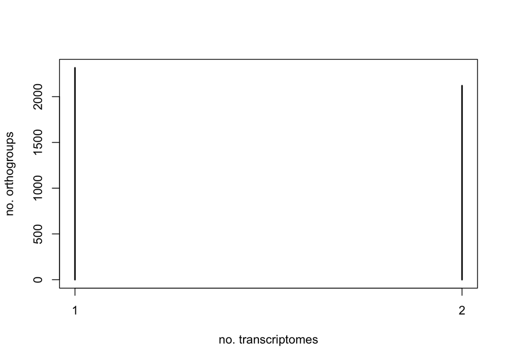

```r
plot(table(apply(orthoSize>0,1,sum)),ylab="no. orthogroups",xlab="no. transcriptomes")
```

**1:1 orthogroups** how many orthogroups have exactly one ortholog in each species

```r
sum(apply(orthoSize==1,1,all)) # number of 1:1 groups
```

```
## [1] 1562
```

*If you are comparing more than 2 species* calulate the number of orthogroups with exactly one ortholog in exactly two of the species

```r
#sum(apply(grpSize==1,1,sum)==2 & apply(grpSize > 1,1,sum)==0)
```

## A) 1:1 orthogroups

```r
names_1.to.1 <- as.data.frame(apply(orthoSize==1,1,all))

names_1.to.1 <- names_1.to.1 %>%
  filter(names_1.to.1$`apply(orthoSize == 1, 1, all)` == TRUE)

names_1.to.1$orthogroups <- rownames(names_1.to.1)
names_1.to.1 <- names_1.to.1[ ,2]
```

```r
ortho_1.to.1  <- orthogroups[names_1.to.1, ]

ortho_1.to.1[sapply(ortho_1.to.1, is.character)] <- lapply(ortho_1.to.1[sapply(ortho_1.to.1, is.character)], as.factor)

dim(ortho_1.to.1)
```

```
## [1] 1562    3
```

```r
head(ortho_1.to.1)
```

```
##                  orthogroup                                           gene_Sid
## N0.HOG0000000 N0.HOG0000000 Siderastrea_Mexico_Barshis-Radice_Host_contig01431
## N0.HOG0000014 N0.HOG0000014 Siderastrea_Mexico_Barshis-Radice_Host_contig14593
## N0.HOG0000023 N0.HOG0000023 Siderastrea_Mexico_Barshis-Radice_Host_contig05917
## N0.HOG0000026 N0.HOG0000026 Siderastrea_Mexico_Barshis-Radice_Host_contig05747
## N0.HOG0000044 N0.HOG0000044 Siderastrea_Mexico_Barshis-Radice_Host_contig14938
## N0.HOG0000046 N0.HOG0000046 Siderastrea_Mexico_Barshis-Radice_Host_contig18894
##                         isotig
## N0.HOG0000000 isotig04050_Past
## N0.HOG0000014    GE911455_Past
## N0.HOG0000023 isotig01016_Past
## N0.HOG0000026 isotig06415_Past
## N0.HOG0000044 isotig24571_Past
## N0.HOG0000046 isotig03223_Past
```

1:1 Past

```r
ortho.1.to.1_Past.isotigs <- past_seq2iso %>%
  inner_join(ortho_1.to.1, by = "isotig")

head(ortho.1.to.1_Past.isotigs)
```

```
##             isotig               gene    orthogroup
## 1 isotig00026_Past isogroup00004_Past N0.HOG0000054
## 2 isotig00203_Past isogroup00042_Past N0.HOG0003158
## 3 isotig00247_Past isogroup00053_Past N0.HOG0000499
## 4 isotig00260_Past isogroup00058_Past N0.HOG0001514
## 5 isotig00290_Past isogroup00070_Past N0.HOG0002456
## 6 isotig00318_Past isogroup00077_Past N0.HOG0001656
##                                             gene_Sid
## 1 Siderastrea_Mexico_Barshis-Radice_Host_contig09373
## 2 Siderastrea_Mexico_Barshis-Radice_Host_contig16711
## 3 Siderastrea_Mexico_Barshis-Radice_Host_contig12729
## 4 Siderastrea_Mexico_Barshis-Radice_Host_contig11158
## 5 Siderastrea_Mexico_Barshis-Radice_Host_contig04006
## 6 Siderastrea_Mexico_Barshis-Radice_Host_contig14224
```

1:1 Ppor

```r
names_1.to.1_ppor <- as.data.frame(apply(orthoSize==1,1,all))

names_1.to.1_ppor <- names_1.to.1_ppor %>%
  filter(names_1.to.1_ppor$`apply(orthoSize == 1, 1, all)` == TRUE)

names_1.to.1_ppor$orthogroups <- rownames(names_1.to.1_ppor)
names_1.to.1_ppor <- names_1.to.1_ppor[ ,2]

ortho_1.to.1_ppor  <- orthogroups[names_1.to.1_ppor, ]

ortho_1.to.1_ppor[sapply(ortho_1.to.1_ppor, is.character)] <- lapply(ortho_1.to.1_ppor[sapply(ortho_1.to.1_ppor, is.character)], as.factor)

ortho.1.to.1_Ppor.isotigs <- seq2iso %>%
  inner_join(ortho_1.to.1_ppor, by = "isotig")

ortho.1.to.1_Ppor.isotigs <- ortho.1.to.1_Ppor.isotigs[ , 3:6]

ortho.1.to.1_Ppor.isotigs <- ortho.1.to.1_Ppor.isotigs %>%
  dplyr::rename(isotig = isotig_Ppor,
                gene = gene_Ppor)

head(ortho.1.to.1_Ppor.isotigs)
```

```
##             isotig               gene    orthogroup
## 1 isotig00026_Ppor isogroup00004_Ppor N0.HOG0000054
## 2 isotig00203_Ppor isogroup00042_Ppor N0.HOG0003158
## 3 isotig00247_Ppor isogroup00053_Ppor N0.HOG0000499
## 4 isotig00260_Ppor isogroup00058_Ppor N0.HOG0001514
## 5 isotig00290_Ppor isogroup00070_Ppor N0.HOG0002456
## 6 isotig00318_Ppor isogroup00077_Ppor N0.HOG0001656
##                                             gene_Sid
## 1 Siderastrea_Mexico_Barshis-Radice_Host_contig09373
## 2 Siderastrea_Mexico_Barshis-Radice_Host_contig16711
## 3 Siderastrea_Mexico_Barshis-Radice_Host_contig12729
## 4 Siderastrea_Mexico_Barshis-Radice_Host_contig11158
## 5 Siderastrea_Mexico_Barshis-Radice_Host_contig04006
## 6 Siderastrea_Mexico_Barshis-Radice_Host_contig14224
```

## B) Multi-orthogroup dataframe

```r
ortho.df <- as.data.frame(ortho.split)
```

use “character(0)” to filter out orthogroups that only belong to one species

```r
ortho.df <- subset(ortho.df, ortho.df$gene_Sid != "character(0)")

ortho.df <- subset(ortho.df, ortho.df$isotig != "character(0)")

dim(ortho.df)
```

```
## [1] 2120    3
```

check for any 1:1 orthogroups

```r
all(rownames(names_1.to.1) %in% rownames(ortho.df))
```

```
## [1] TRUE
```

```r
all(rownames(names_1.to.1) %in% ortho.df$orthogroup)
```

```
## [1] TRUE
```

```r
# any()
```

rownames(names_1.to.1) [1] “N0.HOG0000000” “N0.HOG0000014” “N0.HOG0000023” “N0.HOG0000026” “N0.HOG0000044”

rownames(ortho.df) [1] “N0.HOG0000000” “N0.HOG0000008” “N0.HOG0000009” “N0.HOG0000012” “N0.HOG0000013” [6] “N0.HOG0000014” “N0.HOG0000019” “N0.HOG0000020” “N0.HOG0000021” “N0.HOG0000022” [11] “N0.HOG0000023” “N0.HOG0000024” “N0.HOG0000026” “N0.HOG0000028” “N0.HOG0000029”

so all of the 1:1 orthogroups are in ortho.df

```r
length(match(names_1.to.1, rownames(ortho.df)))
```

```
## [1] 1562
```

```r
#length(names_1.to.1 %in% rownames(ortho.df))
#length(names_1.to.1 %in% ortho.df$orthogroup)
```

*match() requires vectors (not dataframes)* check class of object class(names_1.to.1)

```r
class(names_1.to.1)
```

```
## [1] "character"
```

```r
#typeof(names_1.to.1)
```

A %in% B intersect(A,B) setdiff(A,B)

```r
head(rownames(ortho.df) %in% names_1.to.1)
```

```
## [1]  TRUE FALSE FALSE FALSE FALSE  TRUE
```

```r
names_multi.ortho <- setdiff(rownames(ortho.df), names_1.to.1)
str(names_multi.ortho)
```

```
##  chr [1:558] "N0.HOG0000008" "N0.HOG0000009" "N0.HOG0000012" ...
```

### multi-orthogroups dataframe

```r
multi.ortho  <- orthogroups[names_multi.ortho, ]
head(multi.ortho)
```

```
##                  orthogroup
## N0.HOG0000008 N0.HOG0000008
## N0.HOG0000009 N0.HOG0000009
## N0.HOG0000012 N0.HOG0000012
## N0.HOG0000013 N0.HOG0000013
## N0.HOG0000019 N0.HOG0000019
## N0.HOG0000020 N0.HOG0000020
##                                                                                                                                                                                                                                                                                                          …
## N0.HOG0000008                                                                                                                                                                                                                                                                                            …
## N0.HOG0000009                                                                                                                                                                                                                                                                                            …
## N0.HOG0000012                                                                                                                                                                                                                                                                                            …
## N0.HOG0000013                                                                                                                                                                                                                                                                                            …
## N0.HOG0000019                                                                                                                                                                                                                                                                                            …
## N0.HOG0000020 Siderastrea_Mexico_Barshis-Radice_Host_contig08403, Siderastrea_Mexico_Barshis-Radice_Host_contig13787, Siderastrea_Mexico_Barshis-Radice_Host_contig13289, Siderastrea_Mexico_Barshis-Radice_Host_contig02344, Siderastrea_Mexico_Barshis-Radice_Host_contig00503, Siderastrea_Mexico_Bars…
##                         isotig
## N0.HOG0000008 isotig31162_Past
## N0.HOG0000009 isotig26406_Past
## N0.HOG0000012 isotig31942_Past
## N0.HOG0000013 isotig08204_Past
## N0.HOG0000019 isotig16036_Past
## N0.HOG0000020 isotig05153_Past
```

```r
multi.ortho.Sid <- multi.ortho[ , 1:2]

s <- strsplit(as.character(multi.ortho.Sid$gene_Sid),", ")
head(s, 2)
```

```
## [[1]]
## [1] "Siderastrea_Mexico_Barshis-Radice_Host_contig14809"
## [2] "Siderastrea_Mexico_Barshis-Radice_Host_contig08996"
## [3] "Siderastrea_Mexico_Barshis-Radice_Host_contig18412"
## [4] "Siderastrea_Mexico_Barshis-Radice_Host_contig18850"
## [5] "Siderastrea_Mexico_Barshis-Radice_Host_contig06547"
##
## [[2]]
## [1] "Siderastrea_Mexico_Barshis-Radice_Host_contig12051"
## [2] "Siderastrea_Mexico_Barshis-Radice_Host_contig17467"
## [3] "Siderastrea_Mexico_Barshis-Radice_Host_contig06732"
## [4] "Siderastrea_Mexico_Barshis-Radice_Host_contig17757"
## [5] "Siderastrea_Mexico_Barshis-Radice_Host_contig18511"
## [6] "Siderastrea_Mexico_Barshis-Radice_Host_contig08392"
```

## Siderastrea multi-orthogroup dataframe

```r
multi.ortho.Sid <- multi.ortho[ , 1:2]
multi.ortho.Sid <- separate_rows(multi.ortho.Sid, gene_Sid, sep = ", ")

multi.ortho.Sid[sapply(multi.ortho.Sid, is.character)] <- lapply(multi.ortho.Sid[sapply(multi.ortho.Sid, is.character)],
                                       as.factor)

multi.ortho.Sid <- multi.ortho.Sid %>%
  dplyr::rename(gene = gene_Sid)

dim(multi.ortho.Sid)
```

```
## [1] 1980    2
```

```r
head(multi.ortho.Sid)
```

```
## # A tibble: 6 x 2
##   orthogroup    gene
##   <fct>         <fct>
## 1 N0.HOG0000008 Siderastrea_Mexico_Barshis-Radice_Host_contig14809
## 2 N0.HOG0000008 Siderastrea_Mexico_Barshis-Radice_Host_contig08996
## 3 N0.HOG0000008 Siderastrea_Mexico_Barshis-Radice_Host_contig18412
## 4 N0.HOG0000008 Siderastrea_Mexico_Barshis-Radice_Host_contig18850
## 5 N0.HOG0000008 Siderastrea_Mexico_Barshis-Radice_Host_contig06547
## 6 N0.HOG0000009 Siderastrea_Mexico_Barshis-Radice_Host_contig12051
```

## Porites astreoides multi-orthogroup dataframe

```r
multi.ortho.Past <- multi.ortho[ , c(1,3)]
multi.ortho.Past <- separate_rows(multi.ortho.Past, isotig, sep = ", ")

multi.ortho.Past[sapply(multi.ortho.Past, is.character)] <- lapply(multi.ortho.Past[sapply(multi.ortho.Past, is.character)],
                                       as.factor)

dim(multi.ortho.Past)
```

```
## [1] 1069    2
```

```r
head(multi.ortho.Past)
```

```
## # A tibble: 6 x 2
##   orthogroup    isotig
##   <fct>         <fct>
## 1 N0.HOG0000008 isotig31162_Past
## 2 N0.HOG0000009 isotig26406_Past
## 3 N0.HOG0000012 isotig31942_Past
## 4 N0.HOG0000013 isotig08204_Past
## 5 N0.HOG0000019 isotig16036_Past
## 6 N0.HOG0000020 isotig05153_Past
```

!!! isotig versus isogroup in Past !!!

*Use inner_join() if you only want to retain observations when they match across both data frames.*

```r
multi.ortho.Past.isotigs <- past_seq2iso %>%
  inner_join(multi.ortho.Past, by = "isotig")

head(multi.ortho.Past.isotigs)
```

```
##             isotig               gene    orthogroup
## 1 isotig00011_Past isogroup00002_Past N0.HOG0001065
## 2 isotig00032_Past isogroup00005_Past N0.HOG0000247
## 3 isotig00049_Past isogroup00008_Past N0.HOG0000172
## 4 isotig00067_Past isogroup00011_Past N0.HOG0000255
## 5 isotig00117_Past isogroup00021_Past N0.HOG0000320
## 6 isotig00218_Past isogroup00046_Past N0.HOG0000324
```

### Porites porites multi-orthogroup dataframe

```r
multi.ortho.Ppor.isotigs <- seq2iso %>%
  inner_join(multi.ortho.Past.isotigs, by = "isotig")

multi.ortho.Ppor.isotigs <- multi.ortho.Ppor.isotigs[ , c(3:4,6)]

multi.ortho.Ppor.isotigs <- multi.ortho.Ppor.isotigs %>%
  dplyr::rename(isotig = isotig_Ppor,
                gene = gene_Ppor)

head(multi.ortho.Ppor.isotigs)
```

```
##             isotig               gene    orthogroup
## 1 isotig00011_Ppor isogroup00002_Ppor N0.HOG0001065
## 2 isotig00032_Ppor isogroup00005_Ppor N0.HOG0000247
## 3 isotig00049_Ppor isogroup00008_Ppor N0.HOG0000172
## 4 isotig00067_Ppor isogroup00011_Ppor N0.HOG0000255
## 5 isotig00117_Ppor isogroup00021_Ppor N0.HOG0000320
## 6 isotig00218_Ppor isogroup00046_Ppor N0.HOG0000324
```

# 2. Merge DEG results table for each contrast

### Ojo-Ojo vs. Ojo-Control

OO_OC

P. astreoides vs. Siderastrea

```r
OO_OC_Past <- read.csv("~/Documents/Rprojects/postdoc\ Rprojects/ODU_postdoc_Rprojects/Paper_Ojo_gene-expression/Porites_astreoides/host/Past_Host_DE_genes_OO_OC_padj.1.csv", header = TRUE)

OO_OC_Past$gene <- as.factor(OO_OC_Past$gene)
head(OO_OC_Past)
```

```
##   X               gene    baseMean log2FoldChange     lfcSE      stat
## 1 1 isogroup14250_Past  42377.8579      10.558854 0.9932486 10.630626
## 2 2 isogroup23261_Past   4471.5934       9.770641 0.9661346 10.113126
## 3 3 isogroup06096_Past 109607.3101       9.558681 0.9652750  9.902547
## 4 4 isogroup30333_Past  40950.6399       9.381145 0.9551928  9.821206
## 5 5 isogroup20691_Past    491.9523      10.131877 1.0619126  9.541159
## 6 6 isogroup28947_Past    995.8151       9.275460 1.0070114  9.210878
##         pvalue         padj
## 1 2.146670e-26 7.290091e-23
## 2 4.831747e-24 8.204307e-21
## 3 4.058068e-23 4.593733e-20
## 4 9.124530e-23 7.746726e-20
## 5 1.412446e-21 9.593335e-19
## 6 3.234671e-20 1.830824e-17
```

```r
OO_OC_Sid <- read.csv("~/Documents/Rprojects/postdoc\ Rprojects/ODU_postdoc_Rprojects/Paper_Ojo_gene-expression/Siderastrea/host/Sid_Host_DE_genes_OO_OC_padj.1.csv", header = TRUE)

OO_OC_Sid$gene <- as.factor(OO_OC_Sid$gene)
head(OO_OC_Sid)
```

```
##   X                                               gene baseMean log2FoldChange
## 1 1 Siderastrea_Mexico_Barshis-Radice_Host_contig05154  831.077      -8.186631
##      lfcSE      stat       pvalue         padj
## 1 1.407989 -5.814415 6.084638e-09 4.865885e-05
```

**Sid** *Only one DEG in this comparison*

check if any of the values contained in vector A are also in vector B:

```r
any(OO_OC_Sid$gene %in% multi.ortho.Sid$gene)
```

```
## [1] FALSE
```

Multi-orthogroup

```r
length(intersect(OO_OC_Sid$gene, multi.ortho.Sid$gene))
```

```
## [1] 0
```

1:1 orthogroup

```r
length(intersect(OO_OC_Sid$gene, ortho_1.to.1$gene))
```

```
## [1] 0
```

*Indeed, this gene is in the unassigned gene list, Orthogroups_UnassignedGenes.tsv*

**Past**

Multi-orthogroup

```r
length(intersect(OO_OC_Past$gene, multi.ortho.Past.isotigs$gene))
```

```
## [1] 44
```

1:1 orthogroup

```r
length(intersect(OO_OC_Past$gene, ortho.1.to.1_Past.isotigs$gene))
```

```
## [1] 42
```

```r
past_multi.isogroups_OO_OC <- multi.ortho.Past.isotigs %>%
  inner_join(OO_OC_Past, by = "gene")

dim(past_multi.isogroups_OO_OC)
```

```
## [1] 44 10
```

```r
head(past_multi.isogroups_OO_OC)
```

```
##             isotig               gene    orthogroup   X    baseMean
## 1 isotig00032_Past isogroup00005_Past N0.HOG0000247 194    37.06818
## 2 isotig00067_Past isogroup00011_Past N0.HOG0000255  35 66404.38324
## 3 isotig00593_Past isogroup00157_Past N0.HOG0000138 121    15.02251
## 4 isotig01052_Past isogroup00359_Past N0.HOG0000041 134    22.31753
## 5 isotig01462_Past isogroup00564_Past N0.HOG0001195 141    11.21934
## 6 isotig02288_Past isogroup00977_Past N0.HOG0000205  11  9564.19987
##   log2FoldChange     lfcSE      stat       pvalue         padj
## 1     -0.9530968 0.3183483 -2.993880 2.754540e-03 4.821865e-02
## 2      1.4207196 0.3176532  4.472549 7.729258e-06 7.499588e-04
## 3     -1.0827462 0.3324663 -3.256710 1.127117e-03 3.155255e-02
## 4     -0.9719138 0.3031110 -3.206461 1.343784e-03 3.405590e-02
## 5     -1.0984407 0.3465103 -3.170009 1.524344e-03 3.521545e-02
## 6      6.2732906 0.8139039  7.707655 1.281502e-14 3.956345e-12
```

**orthogroups that are counted more than once in the DEG results table**

```r
past_multi.isogroups_OO_OC %>% count(orthogroup) %>% filter(n > 1)
```

```
##      orthogroup n
## 1 N0.HOG0000041 2
## 2 N0.HOG0000073 2
## 3 N0.HOG0000138 2
## 4 N0.HOG0000255 2
## 5 N0.HOG0000324 2
## 6 N0.HOG0000694 3
## 7 N0.HOG0000888 2
## 8 N0.HOG0001132 2
```

Breakdown of which orthogroups are duplicated

```r
past_multi.isogroups_OO_OC %>%
  group_by(orthogroup) %>%
  filter(n()>1)
```

```
## # A tibble: 17 x 10
## # Groups:   orthogroup [8]
##    isotig   gene   orthogroup     X baseMean log2FoldChange lfcSE  stat   pvalue
##    <fct>    <fct>  <fct>      <int>    <dbl>          <dbl> <dbl> <dbl>    <dbl>
##  1 isotig0… isogr… N0.HOG000…    35   6.64e4          1.42  0.318  4.47 7.73e- 6
##  2 isotig0… isogr… N0.HOG000…   121   1.50e1         -1.08  0.332 -3.26 1.13e- 3
##  3 isotig0… isogr… N0.HOG000…   134   2.23e1         -0.972 0.303 -3.21 1.34e- 3
##  4 isotig0… isogr… N0.HOG000…    10   1.13e4          7.70  0.988  7.80 6.39e-15
##  5 isotig0… isogr… N0.HOG000…   241   5.19e1         -0.761 0.268 -2.84 4.54e- 3
##  6 isotig0… isogr… N0.HOG000…    29   1.90e6          2.32  0.494  4.70 2.60e- 6
##  7 isotig0… isogr… N0.HOG000…   317   1.54e1         -0.923 0.351 -2.63 8.43e- 3
##  8 isotig0… isogr… N0.HOG000…   223   2.87e1         -0.755 0.261 -2.89 3.82e- 3
##  9 isotig0… isogr… N0.HOG000…    57   1.08e2          1.44  0.366  3.93 8.36e- 5
## 10 isotig0… isogr… N0.HOG000…    68   1.58e6          1.27  0.343  3.71 2.07e- 4
## 11 isotig1… isogr… N0.HOG000…    19   2.56e1          1.72  0.309  5.56 2.77e- 8
## 12 isotig1… isogr… N0.HOG000…    28   2.49e4          1.94  0.411  4.71 2.51e- 6
## 13 isotig1… isogr… N0.HOG000…    45   9.75e0          4.98  1.21   4.10 4.09e- 5
## 14 isotig1… isogr… N0.HOG000…    82   8.40e4          1.25  0.358  3.50 4.74e- 4
## 15 isotig1… isogr… N0.HOG000…    65   3.57e5          2.91  0.773  3.76 1.72e- 4
## 16 isotig2… isogr… N0.HOG000…     9   1.46e2          8.84  1.09   8.11 5.26e-16
## 17 GE90986… GE909… N0.HOG000…   237   1.46e1         -1.03  0.360 -2.85 4.30e- 3
## # … with 1 more variable: padj <dbl>
```

1:1 orthogroups

```r
past_1.to.1.isogroups_OO_OC <- ortho.1.to.1_Past.isotigs %>%
  inner_join(OO_OC_Past, by = "gene")

dim(past_1.to.1.isogroups_OO_OC)
```

```
## [1] 42 11
```

```r
head(past_1.to.1.isogroups_OO_OC)
```

```
##             isotig               gene    orthogroup
## 1 isotig01014_Past isogroup00340_Past N0.HOG0002981
## 2 isotig01056_Past isogroup00361_Past N0.HOG0003491
## 3 isotig01094_Past isogroup00380_Past N0.HOG0002042
## 4 isotig01428_Past isogroup00547_Past N0.HOG0001937
## 5 isotig01742_Past isogroup00704_Past N0.HOG0003315
## 6 isotig03223_Past isogroup01491_Past N0.HOG0000046
##                                             gene_Sid   X   baseMean
## 1 Siderastrea_Mexico_Barshis-Radice_Host_contig00518 308  28.550634
## 2 Siderastrea_Mexico_Barshis-Radice_Host_contig07038 187  24.925037
## 3 Siderastrea_Mexico_Barshis-Radice_Host_contig08146 244   9.863968
## 4 Siderastrea_Mexico_Barshis-Radice_Host_contig10844 127  25.192535
## 5 Siderastrea_Mexico_Barshis-Radice_Host_contig08508  51 136.638156
## 6 Siderastrea_Mexico_Barshis-Radice_Host_contig18894  99  20.105038
##   log2FoldChange     lfcSE      stat       pvalue        padj
## 1       1.104844 0.4149764  2.662426 7.757965e-03 0.085539119
## 2       1.100689 0.3641503  3.022624 2.505933e-03 0.045093006
## 3      -1.495465 0.5282819 -2.830809 4.643044e-03 0.064434246
## 4       1.734897 0.5365469  3.233450 1.223048e-03 0.032296222
## 5       1.531111 0.3856976  3.969718 7.195786e-05 0.004757848
## 6      -1.369307 0.4052507 -3.378913 7.277295e-04 0.024963328
```

**orthogroups that are counted more than once in the DEG results table**

```r
past_1.to.1.isogroups_OO_OC %>% count(orthogroup) %>% filter(n > 1)
```

```
## [1] orthogroup n
## <0 rows> (or 0-length row.names)
```

Result: No shared response.

### Ojo-Ojo vs. Lagoon-Ojo

OO_LO

P. astreoides vs. Siderastrea

```r
OO_LO_Past <- read.csv("~/Documents/Rprojects/postdoc\ Rprojects/ODU_postdoc_Rprojects/Paper_Ojo_gene-expression/Porites_astreoides/host/Past_Host_DE_genes_OO_LO_padj.1.csv", header = TRUE)

OO_LO_Past$gene <- as.factor(OO_LO_Past$gene)
head(OO_LO_Past)
```

```
##   X               gene    baseMean log2FoldChange     lfcSE     stat
## 1 1 isogroup20691_Past    491.9523       8.606503 1.1708781 7.350468
## 2 2 isogroup23261_Past   4471.5934       7.953481 1.0894788 7.300263
## 3 3 isogroup14250_Past  42377.8579       7.828426 1.1229098 6.971554
## 4 4 isogroup06096_Past 109607.3101       7.365709 1.0919384 6.745536
## 5 5 isogroup09729_Past    486.5206       9.872050 1.4979539 6.590356
## 6 6 isogroup00977_Past   9564.1999       6.006398 0.9208574 6.522615
##         pvalue         padj
## 1 1.975134e-13 5.103658e-10
## 2 2.872064e-13 5.103658e-10
## 3 3.134590e-12 3.713444e-09
## 4 1.524634e-11 1.354638e-08
## 5 4.387720e-11 3.118792e-08
## 6 6.909216e-11 3.767841e-08
```

```r
OO_LO_Sid <- read.csv("~/Documents/Rprojects/postdoc\ Rprojects/ODU_postdoc_Rprojects/Paper_Ojo_gene-expression/Siderastrea/host/Sid_Host_DE_genes_OO_LO_padj.1.csv", header = TRUE)

OO_LO_Sid$gene <- as.factor(OO_LO_Sid$gene)
head(OO_LO_Sid)
```

```
##   X                                               gene baseMean log2FoldChange
## 1 1 Siderastrea_Mexico_Barshis-Radice_Host_contig12375 43.32329       4.498683
## 2 2 Siderastrea_Mexico_Barshis-Radice_Host_contig19050 47.52530       1.789469
##       lfcSE     stat       pvalue        padj
## 1 0.9132745 4.925883 8.398042e-07 0.006715914
## 2 0.4006966 4.465895 7.973489e-06 0.031881996
```

**Sid** *Only two DEG in this comparison*

check if any of the values contained in vector A are also in vector B:

```r
any(OO_LO_Sid$gene %in% multi.ortho.Sid$gene)
```

```
## [1] FALSE
```

Multi-orthogroup

```r
length(intersect(OO_LO_Sid$gene, multi.ortho.Sid$gene))
```

```
## [1] 0
```

1:1 orthogroup

```r
length(intersect(OO_LO_Sid$gene, ortho_1.to.1$gene))
```

```
## [1] 0
```

*Indeed, both these genes are in the unassigned gene list, Orthogroups_UnassignedGenes.tsv*

**Past**

Multi-orthogroup

```r
length(intersect(OO_LO_Past$gene, multi.ortho.Past.isotigs$gene))
```

```
## [1] 5
```

1:1 orthogroup

```r
length(intersect(OO_LO_Past$gene, ortho.1.to.1_Past.isotigs$gene))
```

```
## [1] 2
```

```r
past_multi.isogroups_OO_LO <- multi.ortho.Past.isotigs %>%
  inner_join(OO_LO_Past, by = "gene")

dim(past_multi.isogroups_OO_LO)
```

```
## [1]  5 10
```

```r
head(past_multi.isogroups_OO_LO)
```

```
##             isotig               gene    orthogroup  X   baseMean
## 1 isotig02288_Past isogroup00977_Past N0.HOG0000205  6  9564.1999
## 2 isotig03357_Past isogroup01625_Past N0.HOG0000938 24    16.7153
## 3 isotig04189_Past isogroup02457_Past N0.HOG0000888  9 11268.8916
## 4 isotig10167_Past isogroup08435_Past N0.HOG0000324 31    25.5805
## 5 isotig25337_Past isogroup23605_Past N0.HOG0000888 12   146.2670
##   log2FoldChange     lfcSE      stat       pvalue         padj
## 1       6.006398 0.9208574  6.522615 6.909216e-11 3.767841e-08
## 2      -1.436409 0.4013156 -3.579250 3.445811e-04 5.102672e-02
## 3       7.185724 1.1175848  6.429690 1.278642e-10 5.049216e-08
## 4       1.160044 0.3416441  3.395476 6.850941e-04 7.854272e-02
## 5       6.894627 1.1833017  5.826602 5.656746e-09 1.675340e-06
```

**orthogroups that are counted more than once in the DEG results table**

```r
past_multi.isogroups_OO_LO %>% count(orthogroup) %>% filter(n > 1)
```

```
##      orthogroup n
## 1 N0.HOG0000888 2
```

Breakdown of which orthogroups are duplicated

```r
past_multi.isogroups_OO_LO %>%
  group_by(orthogroup) %>%
  filter(n()>1)
```

```
## # A tibble: 2 x 10
## # Groups:   orthogroup [1]
##   isotig   gene    orthogroup     X baseMean log2FoldChange lfcSE  stat   pvalue
##   <fct>    <fct>   <fct>      <int>    <dbl>          <dbl> <dbl> <dbl>    <dbl>
## 1 isotig0… isogro… N0.HOG000…     9   11269.           7.19  1.12  6.43 1.28e-10
## 2 isotig2… isogro… N0.HOG000…    12     146.           6.89  1.18  5.83 5.66e- 9
## # … with 1 more variable: padj <dbl>
```

1:1 Past

```r
past_1.to.1.isogroups_OO_LO <- ortho.1.to.1_Past.isotigs %>%
  inner_join(OO_LO_Past, by = "gene")

dim(past_1.to.1.isogroups_OO_LO)
```

```
## [1]  2 11
```

```r
head(past_1.to.1.isogroups_OO_LO)
```

```
##             isotig               gene    orthogroup
## 1 isotig01742_Past isogroup00704_Past N0.HOG0003315
## 2 isotig04307_Past isogroup02575_Past N0.HOG0002752
##                                             gene_Sid  X   baseMean
## 1 Siderastrea_Mexico_Barshis-Radice_Host_contig08508 28 136.638156
## 2 Siderastrea_Mexico_Barshis-Radice_Host_contig08807 26   6.101397
##   log2FoldChange     lfcSE      stat       pvalue       padj
## 1       1.509175 0.4359476  3.461825 0.0005365253 0.06810039
## 2      -2.100403 0.5982951 -3.510648 0.0004470166 0.05884063
```

**orthogroups that are counted more than once in the DEG results table**

```r
past_1.to.1.isogroups_OO_LO %>% count(orthogroup) %>% filter(n > 1)
```

```
## [1] orthogroup n
## <0 rows> (or 0-length row.names)
```

Result: No shared response.

### Lagoon-Ojo vs. Lagoon-Control

LO_LC

P. astreoides vs. Siderastrea

```r
LO_LC_Past <- read.csv("~/Documents/Rprojects/postdoc\ Rprojects/ODU_postdoc_Rprojects/Paper_Ojo_gene-expression/Porites_astreoides/host/Past_Host_DE_genes_LO_LC_padj.1.csv", header = TRUE)

LO_LC_Past$gene <- as.factor(LO_LC_Past$gene)
head(LO_LC_Past)
```

```
##   X               gene  baseMean log2FoldChange     lfcSE      stat
## 1 1 isogroup07295_Past 10.390416      3.9689833 0.7507605  5.286617
## 2 2 isogroup04919_Past  6.437899      2.2624115 0.4583600  4.935883
## 3 3 isogroup06592_Past  5.511236     -3.3493653 0.7556171 -4.432622
## 4 4 isogroup01504_Past 31.746009      1.6081801 0.3807885  4.223290
## 5 5 isogroup25132_Past  4.258410      2.7313864 0.6642264  4.112132
## 6 6      GE907925_Past 19.692604     -0.9743082 0.2539158 -3.837131
##         pvalue         padj
## 1 1.245992e-07 0.0008152527
## 2 7.978874e-07 0.0026102885
## 3 9.309381e-06 0.0203037598
## 4 2.407620e-05 0.0393826519
## 5 3.920225e-05 0.0513000635
## 6 1.244801e-04 0.0639519824
```

*This contrast has zero differentially expressed genes for Siderastrea*

```r
# LO_LC_Sid <- read.csv("~/Documents/Rprojects/postdoc\ Rprojects/ODU_postdoc_Rprojects/Paper_Ojo_gene-expression/Siderastrea/host/Sid_Host_DE_genes_LO_LC_padj.1.csv", header = TRUE)
#
# LO_LC_Sid$gene <- as.factor(LO_LC_Sid$gene)
# head(LO_LC_Sid)
```

Result: Cannot compare because Siderastrea had zero DEG for this contrast.

### Ojo-Control vs. Lagoon-Control

OC_LC

P. astreoides vs. Siderastrea

```r
OC_LC_Past <- read.csv("~/Documents/Rprojects/postdoc\ Rprojects/ODU_postdoc_Rprojects/Paper_Ojo_gene-expression/Porites_astreoides/host/Past_Host_DE_genes_OC_LC_padj.1.csv", header = TRUE)

OC_LC_Past$gene <- as.factor(OC_LC_Past$gene)
head(OC_LC_Past)
```

```
##   X               gene baseMean log2FoldChange     lfcSE     stat       pvalue
## 1 1 isogroup07701_Past 966.8998       2.596819 0.5262138 4.934912 8.018683e-07
##          padj
## 1 0.006507161
```

```r
OC_LC_Sid <- read.csv("~/Documents/Rprojects/postdoc\ Rprojects/ODU_postdoc_Rprojects/Paper_Ojo_gene-expression/Siderastrea/host/Sid_Host_DE_genes_OC_LC_padj.1.csv", header = TRUE)

OC_LC_Sid$gene <- as.factor(OC_LC_Sid$gene)
head(OC_LC_Sid)
```

```
##   X                                               gene baseMean log2FoldChange
## 1 1 Siderastrea_Mexico_Barshis-Radice_Host_contig12108 13.38139      -4.433576
##       lfcSE      stat       pvalue       padj
## 1 0.9956135 -4.453109 8.463558e-06 0.06768307
```

**Sid** *Only one DEG in this comparison*

check if any of the values contained in vector A are also in vector B:

```r
any(OC_LC_Sid$gene %in% multi.ortho.Sid$gene)
```

```
## [1] FALSE
```

Multi-orthogroup list

```r
length(intersect(OC_LC_Sid$gene, multi.ortho.Sid$gene))
```

```
## [1] 0
```

1:1 orthogroup

```r
length(intersect(OC_LC_Sid$gene, ortho_1.to.1$gene))
```

```
## [1] 0
```

*Indeed, this gene is in the unassigned gene list, Orthogroups_UnassignedGenes.tsv*

**Past**

Multi-orthogroup list

```r
length(intersect(OC_LC_Past$gene, multi.ortho.Past.isotigs$gene))
```

```
## [1] 0
```

1:1 orthogroup

```r
length(intersect(OC_LC_Past$gene, ortho.1.to.1_Past.isotigs$gene))
```

```
## [1] 1
```

```r
past_1.to.1.isogroups_OC_LC <- ortho.1.to.1_Past.isotigs %>%
  inner_join(OC_LC_Past, by = "gene")

dim(past_1.to.1.isogroups_OC_LC)
```

```
## [1]  1 11
```

```r
head(past_1.to.1.isogroups_OC_LC)
```

```
##             isotig               gene    orthogroup
## 1 isotig09433_Past isogroup07701_Past N0.HOG0002880
##                                             gene_Sid X baseMean log2FoldChange
## 1 Siderastrea_Mexico_Barshis-Radice_Host_contig17584 1 966.8998       2.596819
##       lfcSE     stat       pvalue        padj
## 1 0.5262138 4.934912 8.018683e-07 0.006507161
```

Result: No shared response.

### Reef-Ojo vs. Reef-Control

RO_RC

P. porites vs. Siderastrea

```r
RO_RC_Ppor <- read.csv("~/Documents/Rprojects/postdoc\ Rprojects/ODU_postdoc_Rprojects/Paper_Ojo_gene-expression/Porites_porites/host/Ppor_Host_DE_genes_RO_RC_padj.1.csv", header = TRUE)

RO_RC_Ppor$gene <- as.factor(RO_RC_Ppor$gene)
head(RO_RC_Ppor)
```

```
##   X               gene   baseMean log2FoldChange     lfcSE     stat
## 1 1 isogroup03915_Ppor 40289.8708       7.981279 1.0924896 7.305588
## 2 2 isogroup28947_Ppor   475.3797       6.947737 0.9951255 6.981770
## 3 3 isogroup14250_Ppor 17852.9885       7.567477 1.1399869 6.638215
## 4 4 isogroup02457_Ppor  3625.3224       6.471598 1.0470853 6.180584
## 5 5 isogroup06096_Ppor 64484.9033       6.776644 1.1464768 5.910842
## 6 6 isogroup23261_Ppor  1163.2734       6.063368 1.0710091 5.661360
##         pvalue         padj
## 1 2.760573e-13 5.184357e-10
## 2 2.914848e-12 2.737043e-09
## 3 3.175056e-11 1.987585e-08
## 4 6.386508e-10 2.998466e-07
## 5 3.403633e-09 1.278405e-06
## 6 1.501781e-08 4.700575e-06
```

```r
RO_RC_Sid <- read.csv("~/Documents/Rprojects/postdoc\ Rprojects/ODU_postdoc_Rprojects/Paper_Ojo_gene-expression/Siderastrea/host/Sid_Host_DE_genes_RO_RC_padj.1.csv", header = TRUE)

RO_RC_Sid$gene <- as.factor(RO_RC_Sid$gene)
head(RO_RC_Sid)
```

```
##   X                                               gene baseMean log2FoldChange
## 1 1 Siderastrea_Mexico_Barshis-Radice_Host_contig09703 61.46572      -2.000779
## 2 2 Siderastrea_Mexico_Barshis-Radice_Host_contig10937 27.41432      -2.195796
## 3 3 Siderastrea_Mexico_Barshis-Radice_Host_contig14719 70.64800       1.799105
## 4 4 Siderastrea_Mexico_Barshis-Radice_Host_contig17010 55.28330       3.195068
## 5 5 Siderastrea_Mexico_Barshis-Radice_Host_contig16766 35.99074       1.831058
## 6 6 Siderastrea_Mexico_Barshis-Radice_Host_contig12808 32.75417      -2.477627
##       lfcSE      stat       pvalue         padj
## 1 0.2961662 -6.755595 1.422507e-11 1.137579e-07
## 2 0.3357427 -6.540115 6.147166e-11 2.457944e-07
## 3 0.2844998  6.323747 2.552949e-10 6.805311e-07
## 4 0.5136133  6.220764 4.947392e-10 9.891073e-07
## 5 0.3217073  5.691688 1.257893e-08 2.011874e-05
## 6 0.4488515 -5.519927 3.391406e-08 4.520179e-05
```

**Sid**

check if any of the values contained in vector A are also in vector B:

```r
any(RO_RC_Sid$gene %in% multi.ortho.Sid$gene)
```

```
## [1] TRUE
```

Multi-orthogroup list

```r
length(intersect(RO_RC_Sid$gene, multi.ortho.Sid$gene))
```

```
## [1] 93
```

1:1 orthogroup

```r
length(intersect(RO_RC_Sid$gene, ortho_1.to.1$gene))
```

```
## [1] 86
```

```r
sid_multi.isogroups_RO_RC <- multi.ortho.Sid %>%
  inner_join(RO_RC_Sid, by = "gene")

dim(sid_multi.isogroups_RO_RC)
```

```
## [1] 93  9
```

```r
head(sid_multi.isogroups_RO_RC)
```

```
## # A tibble: 6 x 9
##   orthogroup  gene         X baseMean log2FoldChange lfcSE  stat  pvalue    padj
##   <fct>       <fct>    <int>    <dbl>          <dbl> <dbl> <dbl>   <dbl>   <dbl>
## 1 N0.HOG0000… Sideras…   214     4.87          -2.39 0.700 -3.42 6.20e-4 0.0227
## 2 N0.HOG0000… Sideras…   632     4.38           1.56 0.566  2.75 5.97e-3 0.0757
## 3 N0.HOG0000… Sideras…   583     2.68           1.76 0.628  2.81 4.97e-3 0.0681
## 4 N0.HOG0000… Sideras…   305    29.5            1.28 0.395  3.24 1.18e-3 0.0309
## 5 N0.HOG0000… Sideras…   373    20.9            1.39 0.447  3.10 1.92e-3 0.0408
## 6 N0.HOG0000… Sideras…    75    20.5            1.32 0.328  4.02 5.79e-5 0.00595
```

**orthogroups that are counted more than once in the DEG results table**

```r
sid_multi.isogroups_RO_RC %>% count(orthogroup) %>% filter(n > 1)
```

```
## # A tibble: 13 x 2
##    orthogroup        n
##    <fct>         <int>
##  1 N0.HOG0000024     6
##  2 N0.HOG0000053     3
##  3 N0.HOG0000055     3
##  4 N0.HOG0000062     3
##  5 N0.HOG0000075     2
##  6 N0.HOG0000079     3
##  7 N0.HOG0000090     2
##  8 N0.HOG0000112     2
##  9 N0.HOG0000119     2
## 10 N0.HOG0000171     2
## 11 N0.HOG0000223     2
## 12 N0.HOG0000395     2
## 13 N0.HOG0000985     2
```

Breakdown of which orthogroups are duplicated

```r
sid_multi.isogroups_RO_RC %>%
  group_by(orthogroup) %>%
  filter(n()>1)
```

```
## # A tibble: 34 x 9
## # Groups:   orthogroup [13]
##    orthogroup  gene        X baseMean log2FoldChange lfcSE  stat  pvalue    padj
##    <fct>       <fct>   <int>    <dbl>          <dbl> <dbl> <dbl>   <dbl>   <dbl>
##  1 N0.HOG0000… Sidera…   583     2.68          1.76  0.628  2.81 4.97e-3 0.0681
##  2 N0.HOG0000… Sidera…   305    29.5           1.28  0.395  3.24 1.18e-3 0.0309
##  3 N0.HOG0000… Sidera…   373    20.9           1.39  0.447  3.10 1.92e-3 0.0408
##  4 N0.HOG0000… Sidera…    75    20.5           1.32  0.328  4.02 5.79e-5 0.00595
##  5 N0.HOG0000… Sidera…   147     6.60         -2.46  0.678 -3.62 2.89e-4 0.0156
##  6 N0.HOG0000… Sidera…   325    39.0           0.890 0.279  3.19 1.42e-3 0.0348
##  7 N0.HOG0000… Sidera…   789    68.3           0.753 0.290  2.60 9.44e-3 0.0960
##  8 N0.HOG0000… Sidera…    48     6.65         -1.99  0.472 -4.21 2.55e-5 0.00421
##  9 N0.HOG0000… Sidera…   191    15.1           1.54  0.440  3.49 4.80e-4 0.0201
## 10 N0.HOG0000… Sidera…   109    14.9           1.87  0.493  3.80 1.44e-4 0.0106
## # … with 24 more rows
```

```r
ortho_1.to.1 <- ortho_1.to.1 %>%
  dplyr::rename(gene = gene_Sid)
```

1:1 orthogroups

```r
sid_1.to.1.isogroups_RO_RC <- ortho_1.to.1 %>%
  inner_join(RO_RC_Sid, by = "gene")

dim(sid_1.to.1.isogroups_RO_RC)
```

```
## [1] 86 10
```

```r
head(sid_1.to.1.isogroups_RO_RC)
```

```
##      orthogroup                                               gene
## 1 N0.HOG0000054 Siderastrea_Mexico_Barshis-Radice_Host_contig09373
## 2 N0.HOG0000160 Siderastrea_Mexico_Barshis-Radice_Host_contig02604
## 3 N0.HOG0000197 Siderastrea_Mexico_Barshis-Radice_Host_contig13675
## 4 N0.HOG0000219 Siderastrea_Mexico_Barshis-Radice_Host_contig16246
## 5 N0.HOG0000291 Siderastrea_Mexico_Barshis-Radice_Host_contig15330
## 6 N0.HOG0000370 Siderastrea_Mexico_Barshis-Radice_Host_contig08185
##             isotig   X  baseMean log2FoldChange     lfcSE      stat
## 1 isotig00026_Past 263 125.84712       0.710396 0.2134770  3.327740
## 2 isotig21641_Past 501  17.38829      -1.104596 0.3804733 -2.903217
## 3 isotig24643_Past 311  22.03542       1.431816 0.4434823  3.228576
## 4 isotig13287_Past 317  27.59493      -1.244969 0.3874327 -3.213381
## 5 isotig04495_Past 660  53.36763      -1.290974 0.4766675 -2.708332
## 6 isotig28215_Past  63  45.42940      -1.709211 0.4180491 -4.088541
##         pvalue        padj
## 1 0.0008755339 0.026622223
## 2 0.0036935106 0.058441590
## 3 0.0012440838 0.032052227
## 4 0.0013118219 0.033093502
## 5 0.0067622340 0.081935736
## 6 0.0000434094 0.005223159
```

**orthogroups that are counted more than once in the DEG results table**

```r
sid_1.to.1.isogroups_RO_RC %>% count(orthogroup) %>% filter(n > 1)
```

```
## [1] orthogroup n
## <0 rows> (or 0-length row.names)
```

**P. porites**

Multi-orthogroup list

```r
length(intersect(RO_RC_Ppor$gene, multi.ortho.Ppor.isotigs$gene))
```

```
## [1] 3
```

```r
ppor_multi.isogroups_RO_RC <- multi.ortho.Ppor.isotigs %>%
  inner_join(RO_RC_Ppor, by = "gene")

dim(ppor_multi.isogroups_RO_RC)
```

```
## [1]  3 10
```

```r
head(ppor_multi.isogroups_RO_RC)
```

```
##             isotig               gene    orthogroup  X  baseMean log2FoldChange
## 1 isotig01438_Ppor isogroup00552_Ppor N0.HOG0001198 12   13.5909       3.888921
## 2 isotig04189_Ppor isogroup02457_Ppor N0.HOG0000888  4 3625.3224       6.471598
## 3 isotig25337_Ppor isogroup23605_Ppor N0.HOG0000888 13  230.7912       6.100478
##      lfcSE     stat       pvalue         padj
## 1 1.136181 3.422802 6.197926e-04 9.699754e-02
## 2 1.047085 6.180584 6.386508e-10 2.998466e-07
## 3 1.797213 3.394409 6.877690e-04 9.935617e-02
```

**orthogroups that are counted more than once in the DEG results table**

```r
ppor_multi.isogroups_RO_RC %>% count(orthogroup) %>% filter(n > 1)
```

```
##      orthogroup n
## 1 N0.HOG0000888 2
```

Breakdown of which orthogroups are duplicated

```r
ppor_multi.isogroups_RO_RC %>%
  group_by(orthogroup) %>%
  filter(n()>1)
```

```
## # A tibble: 2 x 10
## # Groups:   orthogroup [1]
##   isotig   gene    orthogroup     X baseMean log2FoldChange lfcSE  stat   pvalue
##   <fct>    <fct>   <fct>      <int>    <dbl>          <dbl> <dbl> <dbl>    <dbl>
## 1 isotig0… isogro… N0.HOG000…     4    3625.           6.47  1.05  6.18 6.39e-10
## 2 isotig2… isogro… N0.HOG000…    13     231.           6.10  1.80  3.39 6.88e- 4
## # … with 1 more variable: padj <dbl>
```

1:1 orthogroup

```r
length(intersect(RO_RC_Ppor$gene, ortho.1.to.1_Ppor.isotigs$gene))
```

```
## [1] 0
```

Check for overlapping orthogroups between multi-orthogroup Sid and P.por

```r
length(intersect(sid_multi.isogroups_RO_RC$orthogroup, ppor_multi.isogroups_RO_RC$orthogroup))
```

```
## [1] 0
```

Result: No shared DEG.

If there are any shared DEG:

## filter by DEG direction

### up-regulated

```r
# OO_OC_up <- OO_OC %>%
#     filter(baseMean > 0 & padj < 0.1)
```

### down-regulated

```r
# OO_OC_down <- OO_OC %>%
#     filter(baseMean < 0 & padj < 0.1)
```